# Assignment B

## Instructions

1. You may talk to a friend, discuss the questions and potential directions for solving them. However, you need to write your own solutions and code separately, and not as a group activity.
2. Do not write your name on the assignment.
3. Write your code in the *Code* cells and your answer in the *Markdown* cells of the Jupyter notebook. Ensure that the solution is written neatly enough to understand and grade.
4. Use [Quarto](https://quarto.org/docs/output-formats/html-basics.html) to print the *.ipynb* file as HTML. You will need to open the command prompt, navigate to the directory containing the file, and use the command: `quarto render filename.ipynb --to html`. Submit the HTML file.
5. The assignment is worth 100 points, and is due on **Thursday, 26th January 2023 at 11:59 pm**.
6. **Five points are properly formatting the assignment**. The breakdown is as follows:
- Must be an HTML file rendered using Quarto (1 pt). *If you have a Quarto issue, you must mention the issue & quote the error you get when rendering using Quarto in the comments section of Canvas, and submit the ipynb file.*
- No name can be written on the assignment, nor can there be any indicator of the student’s identity—e.g. printouts of the working directory should not be included in the final submission (1 pt)
- There aren’t excessively long outputs of extraneous information (e.g. no printouts of entire data frames without good reason, there aren’t long printouts of which iteration a loop is on, there aren’t long sections of commented-out code, etc.) (1 pt)
- Final answers of each question are written in Markdown cells (1 pt).
- There is no piece of unnecessary / redundant code, and no unnecessary / redundant text (1 pt)

## Multiple linear regression

A study was conducted on 97 men with prostate cancer who were due to receive a radical prostatectomy. The dataset *prostate.csv* contains data on 9 measurements made on these 97 men. The description of variables can be found here: https://rafalab.github.io/pages/649/prostate.html

Fit a linear regression model with `lpsa` as the response and the other variables as the predictors. Write down the equation to predict `lpsa` based on the other eight variables.

*(2+2 points)*

```python
import pandas as pd
import seaborn as sns
import statsmodels.formula.api as smf
import numpy as np
import matplotlib.pyplot as plt
```

```python
prostate = pd.read_csv('./Datasets/prostate.csv')
predictors=list(prostate.columns)
predictors.remove('lpsa')
predictors = "+".join(predictors)
model = smf.ols(formula='lpsa~'+predictors, data=prostate).fit()
model.summary()
```

OLS Regression Results

| Dep. Variable: | lpsa | R-squared: | 0.655 |
| --- | --- | --- | --- |
| Model: | OLS | Adj. R-squared: | 0.623 |
| Method: | Least Squares | F-statistic: | 20.86 |
| Date: | Tue, 17 Jan 2023 | Prob (F-statistic): | 2.24e-17 |
| Time: | 09:58:35 | Log-Likelihood: | -99.476 |
| No. Observations: | 97 | AIC: | 217.0 |
| Df Residuals: | 88 | BIC: | 240.1 |
| Df Model: | 8 |  |  |
| Covariance Type: | nonrobust |  |  |

|  | coef | std err | t | P>\|t\| | [0.025 | 0.975] |
| --- | --- | --- | --- | --- | --- | --- |
| Intercept | 0.6693 | 1.296 | 0.516 | 0.607 | -1.907 | 3.246 |
| lcavol | 0.5870 | 0.088 | 6.677 | 0.000 | 0.412 | 0.762 |
| lweight | 0.4545 | 0.170 | 2.673 | 0.009 | 0.117 | 0.792 |
| age | -0.0196 | 0.011 | -1.758 | 0.082 | -0.042 | 0.003 |
| lbph | 0.1071 | 0.058 | 1.832 | 0.070 | -0.009 | 0.223 |
| svi | 0.7662 | 0.244 | 3.136 | 0.002 | 0.281 | 1.252 |
| lcp | -0.1055 | 0.091 | -1.159 | 0.250 | -0.286 | 0.075 |
| gleason | 0.0451 | 0.157 | 0.287 | 0.775 | -0.268 | 0.358 |
| pgg45 | 0.0045 | 0.004 | 1.024 | 0.309 | -0.004 | 0.013 |

| Omnibus: | 0.235 | Durbin-Watson: | 1.507 |
| --- | --- | --- | --- |
| Prob(Omnibus): | 0.889 | Jarque-Bera (JB): | 0.026 |
| Skew: | -0.017 | Prob(JB): | 0.987 |
| Kurtosis: | 3.073 | Cond. No. | 1.28e+03 |

Notes:  
[1] Standard Errors assume that the covariance matrix of the errors is correctly specified.  
[2] The condition number is large, 1.28e+03. This might indicate that there are  
strong multicollinearity or other numerical problems.

The prediction equation is lpsa = 0.669+0.587 * lcavol + 0.454l * weight − 0.020 * age + 0.107l * bph + 0.766 * svi − 0.105 * lcp + 0.045 * gleason + 0.005 * pgg45

Is the regression significant at 5% level? Justify your answer.

*(2 points)*

For the overall significance of the regression, we get $F = 20.86$ with 8 and 88 degrees of freedom. The $p$−value = 2.2 × 10−17 is extremely small indicating that the regression is highly significant.

Interpert the coefficient of `svi`.

*(2 points)*

For a **unit** increase in `svi`, the **expected** increase in `lpsa` is 0.7662 units, assuming the values of all the other predictors are **constant**.

Report the $p$-values for `gleason` and `age`. What do you conclude about the significance of these variables?

*(2+2 points)*

The $p$-value of the `age` variable is 0.08229. This variable is not significant at 5% level, but is significant at 10% level. So, overall, it is a marginally significant variable.

The $p$-value of the `gleason` variable is 0.775. As this value is too high, this variable is insignificant.

What is the 95% confidence interval for the coefficient of `age`? Can you conclude anything about its significance based on the confidence interval?

*(2+2 points)*

The 95% confidence interval for the coefficient of age is [ -0.042 0.003 ]. We can see that the 95% confidence interval includes 0 and therefore, this variable is not significant at 5% level.

Fit a simple linear regression on `lpsa` against `gleason`. What is the $p$-value for `gleason`?

*(1+1 points)*

```python
model = smf.ols(formula='lpsa~gleason', data=prostate).fit()
model.summary()
```

OLS Regression Results

| Dep. Variable: | lpsa | R-squared: | 0.136 |
| --- | --- | --- | --- |
| Model: | OLS | Adj. R-squared: | 0.127 |
| Method: | Least Squares | F-statistic: | 14.97 |
| Date: | Tue, 17 Jan 2023 | Prob (F-statistic): | 0.000200 |
| Time: | 03:03:57 | Log-Likelihood: | -143.96 |
| No. Observations: | 97 | AIC: | 291.9 |
| Df Residuals: | 95 | BIC: | 297.1 |
| Df Model: | 1 |  |  |
| Covariance Type: | nonrobust |  |  |

|  | coef | std err | t | P>\|t\| | [0.025 | 0.975] |
| --- | --- | --- | --- | --- | --- | --- |
| Intercept | -1.5044 | 1.035 | -1.453 | 0.149 | -3.559 | 0.550 |
| gleason | 0.5898 | 0.152 | 3.869 | 0.000 | 0.287 | 0.892 |

| Omnibus: | 2.099 | Durbin-Watson: | 0.245 |
| --- | --- | --- | --- |
| Prob(Omnibus): | 0.350 | Jarque-Bera (JB): | 1.526 |
| Skew: | 0.178 | Prob(JB): | 0.466 |
| Kurtosis: | 3.501 | Cond. No. | 65.6 |

Notes:  
[1] Standard Errors assume that the covariance matrix of the errors is correctly specified.

Is the predictor `gleason` statistically significant in the model developed in the previous question *(where it is the only predictor)?

Was `gleason` statistically significant in the model developed in the first question with multiple predictors?

Did the statistical significance of `gleason` change in the absence of other predictors? Why or why not?

*(1+1+4 points)*

The predictor `gleason` appears to be statisticaly significant in the simple linear regression model, but insignificant in the multiple linear regression model.

This is not surprising as the hypotheses being tested in the two models are different.

For the simple linear regression model, the hypothesis being tested is:

$H_0 : E(y) = \beta_0$ against $H_1 : E(y) = \beta_0 + \beta_1$`gleason`,

We can further explain this observation with the help of the correlation table below.

```python
prostate.corr()
```

|  | lcavol | lweight | age | lbph | svi | lcp | gleason | pgg45 | lpsa |
| --- | --- | --- | --- | --- | --- | --- | --- | --- | --- |
| lcavol | 1.000000 | 0.194128 | 0.225000 | 0.027350 | 0.538845 | 0.675311 | 0.432417 | 0.433652 | 0.734460 |
| lweight | 0.194128 | 1.000000 | 0.307525 | 0.434932 | 0.108778 | 0.100239 | -0.001283 | 0.050846 | 0.354122 |
| age | 0.225000 | 0.307525 | 1.000000 | 0.350186 | 0.117658 | 0.127668 | 0.268892 | 0.276112 | 0.169593 |
| lbph | 0.027350 | 0.434932 | 0.350186 | 1.000000 | -0.085843 | -0.006999 | 0.077820 | 0.078460 | 0.179810 |
| svi | 0.538845 | 0.108778 | 0.117658 | -0.085843 | 1.000000 | 0.673111 | 0.320412 | 0.457648 | 0.566218 |
| lcp | 0.675311 | 0.100239 | 0.127668 | -0.006999 | 0.673111 | 1.000000 | 0.514830 | 0.631528 | 0.548813 |
| gleason | 0.432417 | -0.001283 | 0.268892 | 0.077820 | 0.320412 | 0.514830 | 1.000000 | 0.751905 | 0.368987 |
| pgg45 | 0.433652 | 0.050846 | 0.276112 | 0.078460 | 0.457648 | 0.631528 | 0.751905 | 1.000000 | 0.422316 |
| lpsa | 0.734460 | 0.354122 | 0.169593 | 0.179810 | 0.566218 | 0.548813 | 0.368987 | 0.422316 | 1.000000 |

Note that `gleason` is somewhat correlated with `lcavol`, and `lcavol` is highly statisticaly significant. In the simple linear regression model, the coefficient of `gleason` represents the average change in `lpsa` with a unit change in `gleason`, ignoring other predictors such as `lcavol`. However, in the multiple linear regression model, the coefficient of `gleason` represents the average change in `lpsa` with a unit change in `gleason` holding the other predictors such as `lcavol` constant. This shows that `gleason`, when by itself, is a surrogate for other statistically significant predictors such ad `lcavol`, and actually does not have a statistically significant relationship with `lpsa`.

Predict `lpsa` of a 65-year old man with `lcavol` = 1.35, `lweight` = 3.65, `lbph` = 0.1, `svi` = 0.22, `lcp` = -0.18, `gleason` = 6.75, and `pgg45` = 25 and find 95% prediction intervals.

*(2 points)*

```python
predictor_vals=pd.DataFrame({'lcavol':[1.35], 'lweight': 3.65, 'lbph': 0.1,'svi': [0.22],'lcp': [-0.18],'gleason': [6.75],'pgg45': [25],'age':65})
model.predict(predictor_vals)
```

```
0    2.476867
dtype: float64
```

```python
intervals = model.get_prediction(predictor_vals)
intervals.summary_frame(alpha=0.05)
```

|  | mean | mean_se | mean_ci_lower | mean_ci_upper | obs_ci_lower | obs_ci_upper |
| --- | --- | --- | --- | --- | --- | --- |
| 0 | 2.476867 | 0.109506 | 2.259469 | 2.694264 | 0.324755 | 4.628979 |

Find the largest subset of predictors in the model developed in the first question, such that their coefficients are zero, i.e., none of the predictors in the subset are statistically significant.

Does the model $R$-squared change a lot if you remove the set of predictors identifed above from the model in the first question?

**Hint:** You may use the `f_test()` method to test hypotheses.

*(4+1 points)*

```python
model = smf.ols(formula='lpsa~'+predictors, data=prostate).fit()
```

```python
hypotheses = '(gleason = 0, pgg45 = 0, lcp=0, age=0, lbph=0)'
f_test = model.f_test(hypotheses)
print(f_test)
```

```
<F test: F=array([[1.44338692]]), p=0.21673336075540003, df_denom=88, df_num=5>
```

The coefficients of 5 predictors - `gleason`, `pgg45`, `lcp`, `age`, and `lbph` is zero.

```python
model = smf.ols(formula='lpsa~lcavol+ lweight+ svi', data=prostate).fit()
model.rsquared
```

```
0.6264402535532444
```

There is a very small change in the model $R$-squared, if we remove the set of insignificant predictors.

## Using MLR coefficients and variable transformation

The dataset *infmort.csv* gives the infant mortality of different countries in the world. The column `mortality` gives the infant mortality in deaths per 1000 births.

Make the following plots (i) a boxplot of log(`mortality`) against `region` *(note that a plot of log(`mortality`) against `region` better distinguishes the mortality among regions as compared to a plot of `mortaility` against `region`*, (ii) a boxplot of `income` against `region`, and (iii) a scatter plot of `mortality` against `income`.

What trends do you see in these plots? *Mention the trend separately for each plot.*

*(3+2 points)*

```python
infmort = pd.read_csv('./Datasets/infmort.csv')
```

```python
infmort['log_mortality'] = np.log(infmort.mortality)
```

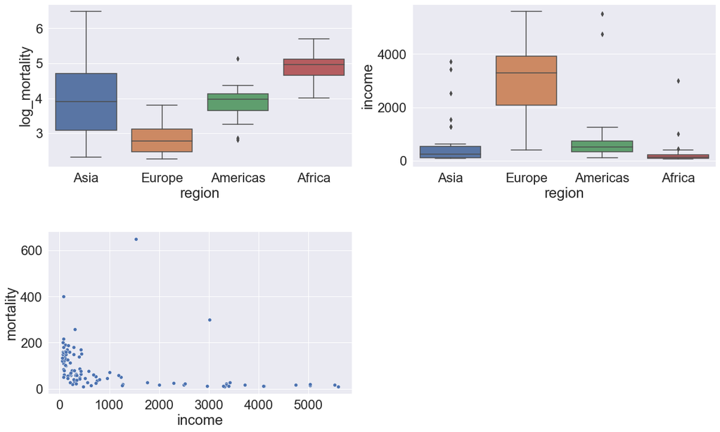

```python
fig = plt.figure()
fig.subplots_adjust(hspace=0.4, wspace=0.2)
sns.set(rc = {'figure.figsize':(20,12)})
sns.set(font_scale = 2)
ax = fig.add_subplot(2, 2, 1)
sns.boxplot(x = 'region', y = 'log_mortality', data = infmort)
ax = fig.add_subplot(2, 2, 2)
sns.boxplot(x = 'region', y = 'income', data = infmort)
ax = fig.add_subplot(2, 2, 3)
sns.scatterplot(x = 'income', y = 'mortality', data = infmort)
```

The first boxplot (top, left) shows that many countries in Europe have low mortality, whereas African countries have high mortality. The second boxplot (top, right) shows that many Europian countries have high per capita income, whereas African countries have low per capita income. The scatterplot shows an inverse relationship between mortality and income, that is, mortality seems to decrease with increase in income.

Europe seems to have the lowest infant mortality, but it also has the highest per capita annual income. We want to see if Europe still has the lowest mortality if we remove the effect of income from the mortality. We will answer this question with the following steps.

Plot (1) `mortality` against `income`, (2) log(`mortality`) against `income`, (3) `mortality` against log(`income`), and (4) log(`mortality`) against log(`income`). Based on the plots, postulate an appropriate model to predict mortality as a function of income. *Print the model summary.*

*(2+4 points)*

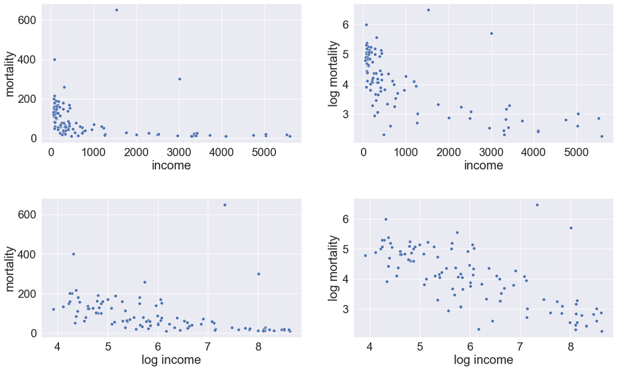

```python
####
fig = plt.figure()
fig.subplots_adjust(hspace=0.4, wspace=0.2)
sns.set(rc = {'figure.figsize':(20,12)})
sns.set(font_scale = 2)
ax = fig.add_subplot(2, 2, 1)
sns.scatterplot(x = 'income', y = 'mortality', data = infmort)
ax = fig.add_subplot(2, 2, 2)
p2 = sns.scatterplot(x = infmort.income, y = np.log(infmort.mortality))
p2.set_ylabel('log mortality')
ax = fig.add_subplot(2, 2, 3)
p3 = sns.scatterplot(x = np.log(infmort.income), y = 'mortality', data = infmort)
p3.set_xlabel('log income')
ax = fig.add_subplot(2, 2, 4)
p4 = sns.scatterplot(x = np.log(infmort.income), y = np.log(infmort.mortality))
p4.set_xlabel('log income')
p4.set_ylabel('log mortality')
```

From these plots a linear model for log(mortality) against log(income) seems appropriate. Below is the regression.

```python
model = smf.ols(formula='np.log(mortality)~np.log(income)',data = infmort).fit()
model.summary()
```

OLS Regression Results

| Dep. Variable: | np.log(mortality) | R-squared: | 0.502 |
| --- | --- | --- | --- |
| Model: | OLS | Adj. R-squared: | 0.497 |
| Method: | Least Squares | F-statistic: | 99.84 |
| Date: | Tue, 17 Jan 2023 | Prob (F-statistic): | 1.14e-16 |
| Time: | 10:50:54 | Log-Likelihood: | -104.34 |
| No. Observations: | 101 | AIC: | 212.7 |
| Df Residuals: | 99 | BIC: | 217.9 |
| Df Model: | 1 |  |  |
| Covariance Type: | nonrobust |  |  |

|  | coef | std err | t | P>\|t\| | [0.025 | 0.975] |
| --- | --- | --- | --- | --- | --- | --- |
| Intercept | 7.1458 | 0.317 | 22.575 | 0.000 | 6.518 | 7.774 |
| np.log(income) | -0.5118 | 0.051 | -9.992 | 0.000 | -0.613 | -0.410 |

| Omnibus: | 38.668 | Durbin-Watson: | 1.898 |
| --- | --- | --- | --- |
| Prob(Omnibus): | 0.000 | Jarque-Bera (JB): | 129.408 |
| Skew: | 1.255 | Prob(JB): | 7.93e-29 |
| Kurtosis: | 7.945 | Cond. No. | 29.3 |

Notes:  
[1] Standard Errors assume that the covariance matrix of the errors is correctly specified.

Update the model developed in the previous question by adding `region` as a predictor. Print the model summary.

*(2 points)*

```python
model = smf.ols(formula='np.log(mortality)~region+np.log(income)',data = infmort).fit()
model.summary()
```

OLS Regression Results

| Dep. Variable: | np.log(mortality) | R-squared: | 0.616 |
| --- | --- | --- | --- |
| Model: | OLS | Adj. R-squared: | 0.600 |
| Method: | Least Squares | F-statistic: | 38.55 |
| Date: | Tue, 17 Jan 2023 | Prob (F-statistic): | 3.29e-19 |
| Time: | 10:51:29 | Log-Likelihood: | -91.189 |
| No. Observations: | 101 | AIC: | 192.4 |
| Df Residuals: | 96 | BIC: | 205.5 |
| Df Model: | 4 |  |  |
| Covariance Type: | nonrobust |  |  |

|  | coef | std err | t | P>\|t\| | [0.025 | 0.975] |
| --- | --- | --- | --- | --- | --- | --- |
| Intercept | 6.4030 | 0.358 | 17.871 | 0.000 | 5.692 | 7.114 |
| region[T.Americas] | -0.6022 | 0.190 | -3.166 | 0.002 | -0.980 | -0.225 |
| region[T.Asia] | -0.7233 | 0.163 | -4.431 | 0.000 | -1.047 | -0.399 |
| region[T.Europe] | -1.2028 | 0.259 | -4.647 | 0.000 | -1.717 | -0.689 |
| np.log(income) | -0.2994 | 0.067 | -4.441 | 0.000 | -0.433 | -0.166 |

| Omnibus: | 44.959 | Durbin-Watson: | 1.847 |
| --- | --- | --- | --- |
| Prob(Omnibus): | 0.000 | Jarque-Bera (JB): | 174.758 |
| Skew: | 1.428 | Prob(JB): | 1.13e-38 |
| Kurtosis: | 8.777 | Cond. No. | 42.8 |

Notes:  
[1] Standard Errors assume that the covariance matrix of the errors is correctly specified.

Use the model developed in the previous question to compute `adjusted_mortality` for each observation in the data, where adjusted mortality is the mortality after removing the estimated effect of income. Make a boxplot of log(`adjusted_mortality`) against `region`.

*(4+2 points)*

```python
adj_mortality = np.exp(np.log(infmort.mortality) - model.params['np.log(income)']*np.log(infmort.income))
```

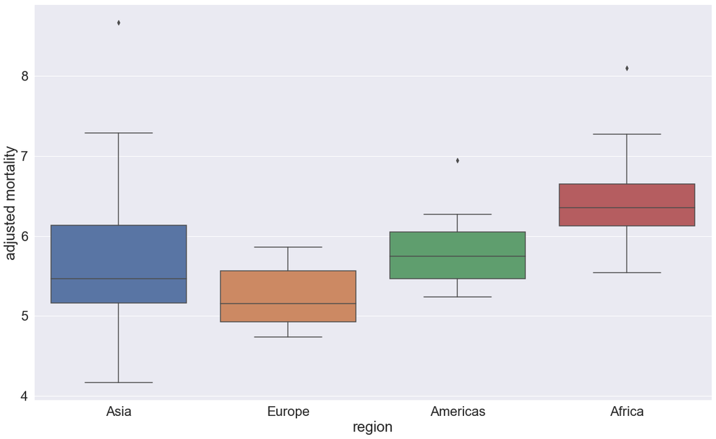

```python
p = sns.boxplot(x = infmort.region, y = np.log(adj_mortality))
p.set_ylabel('adjusted mortality')
```

From the plot in the previous question:

1. Does Europe still seem to have the lowest mortality as compared to other regions after removing the effect of income from mortality?
2. After adjusting for income, is there any change in the mortality comparison among different regions. Compare the plot developed in the previous question to the plot of `log(mortality)` against `region` developed earlier to answer this question.

**Hint:** Do any African / Asian / American countries seem to do better than all the European countries with regard to mortality after adjusting for income?

*(1+3 points)*

Yes, Europe still has the lowest mortality, on an average. However, once we adjust for the income, some of the Asian countries seem to be doing better than the European countries.

## Variable transformations and interactions

The dataset *soc_ind.csv* contains the GDP per capita of some countries along with several social indicators.

For a simple linear regression model predicting `gdpPerCapita`. Which predictor will provide the best model fit *(ignore categorical predictors)*? Let that predictor be $P$.

*(2 points)*

```python
social_indicators = pd.read_csv('./Datasets/soc_ind.csv')
social_indicators.corrwith(social_indicators.gdpPerCapita)
```

```
Index                     0.073671
economicActivityFemale    0.052964
economicActivityMale     -0.167231
gdpPerCapita              1.000000
illiteracyFemale         -0.457012
illiteracyMale           -0.471689
infantMortality          -0.584060
lifeFemale                0.604029
lifeMale                  0.592267
dtype: float64
```

As `lifeFemale` has the highest linear correlation with `gdpPerCapita`, it will provide the best model fit.

Make a scatterplot of `gdpPerCapita` vs $P$. Does the relationship between `gdpPerCapita` and $P$ seem linear or non-linear?

*(1 + 2 points)*

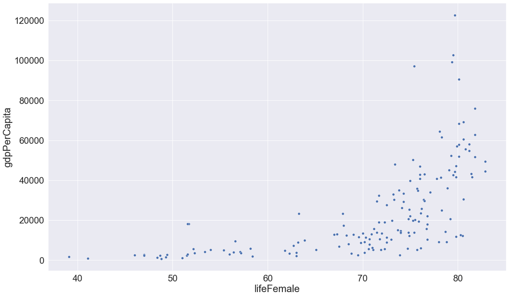

```python
sns.scatterplot(x = social_indicators.lifeFemale, y = social_indicators.gdpPerCapita);
```

Based on the scatterplot above, the relationship between *gdpPerCapita* and *lifeFemale* seems non-linear.

If the relationship identified in the previous question is non-linear, identify and include transformation(s) of the predictor $P$ in the model to improve the model fit.

Mention the predictors of the transformed model, and report the change in the $R$-squared value of the transformed model as compared to the simple linear regression model with only $P$.

*(4+4 points)*

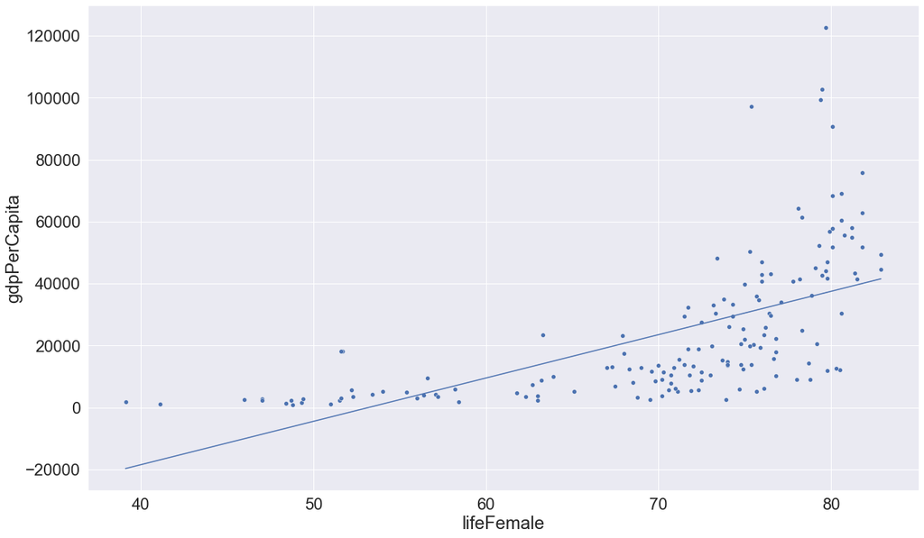

```python
#Visualzing model fit with only P as predictor
model = smf.ols(formula='gdpPerCapita~lifeFemale',data = social_indicators).fit()
sns.scatterplot(x = social_indicators.lifeFemale, y = social_indicators.gdpPerCapita)
sns.lineplot(x = social_indicators.lifeFemale, y = model.fittedvalues)
```

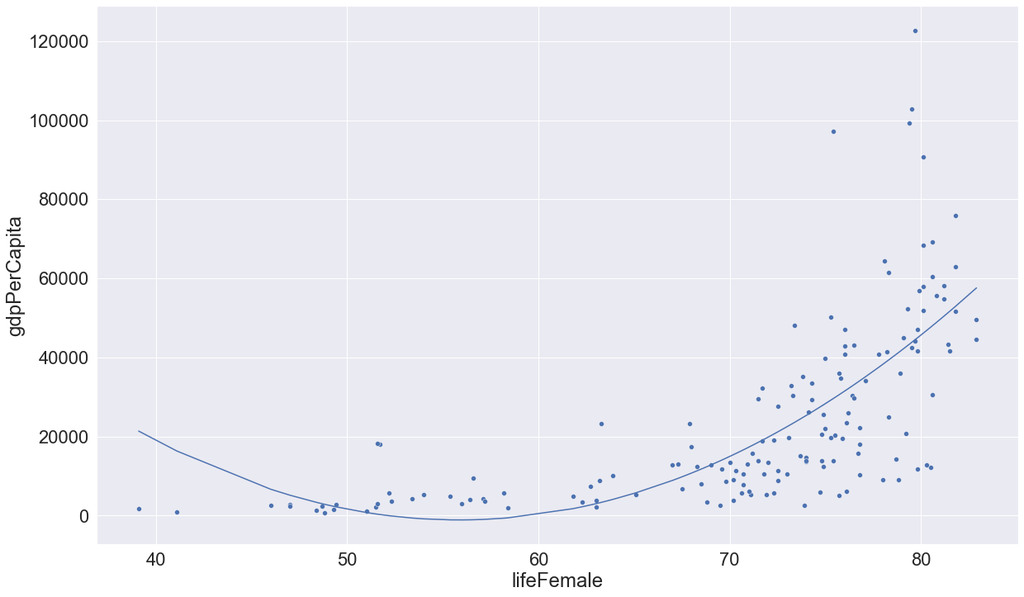

```python
#Adding square of lifeFemale as a predictor and visualizing model fit
model = smf.ols(formula='gdpPerCapita~lifeFemale+I(lifeFemale**2)',data = social_indicators).fit()
sns.scatterplot(x = social_indicators.lifeFemale, y = social_indicators.gdpPerCapita)
sns.lineplot(x = social_indicators.lifeFemale, y = model.fittedvalues)
```

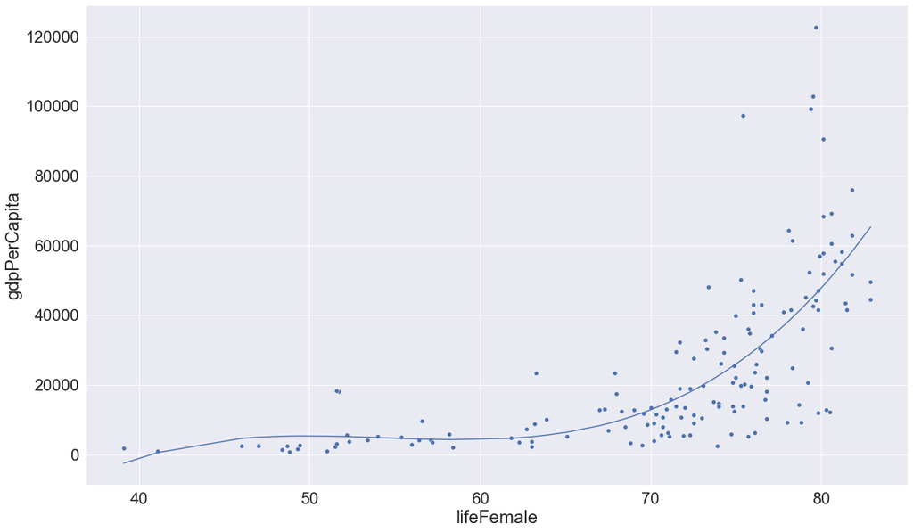

```python
#Adding square and cube of lifeFemale as predictors and visualizing model fit
model = smf.ols(formula='gdpPerCapita~lifeFemale+I(lifeFemale**2)+I(lifeFemale**3)',data = social_indicators).fit()
sns.scatterplot(x = social_indicators.lifeFemale, y = social_indicators.gdpPerCapita)
sns.lineplot(x = social_indicators.lifeFemale, y = model.fittedvalues)
```

The squared and cube transformations of `lifeFemale` seem to provide a better model fit than previous models.

```python
#R-squared of the simple linear regression model with only P as predictor
model = smf.ols(formula='gdpPerCapita~lifeFemale',data = social_indicators).fit()
model.rsquared
```

```
0.3648504777962377
```

```python
#R-squared of the transformed model
model = smf.ols(formula='gdpPerCapita~lifeFemale+I(lifeFemale**2)+I(lifeFemale**3)',data = social_indicators).fit()
model.rsquared
```

```
0.5216581673999969
```

The predictors of the transformed model are `lifeFemale`, `lifeFemale`$^2$, and `lifeFemale`$^3$

The $R$-squared of the model with transformed model is around 16 percentage points higher than the $R$-squared of the model with only $P$.

Plot the regression curve of the transformed model (developed in the previous question) over the scatterplot in (b) to visualize model fit. Also make the regression line of the simple linear regression model with only $P$ on the same plot.

*(3 + 1 points)*

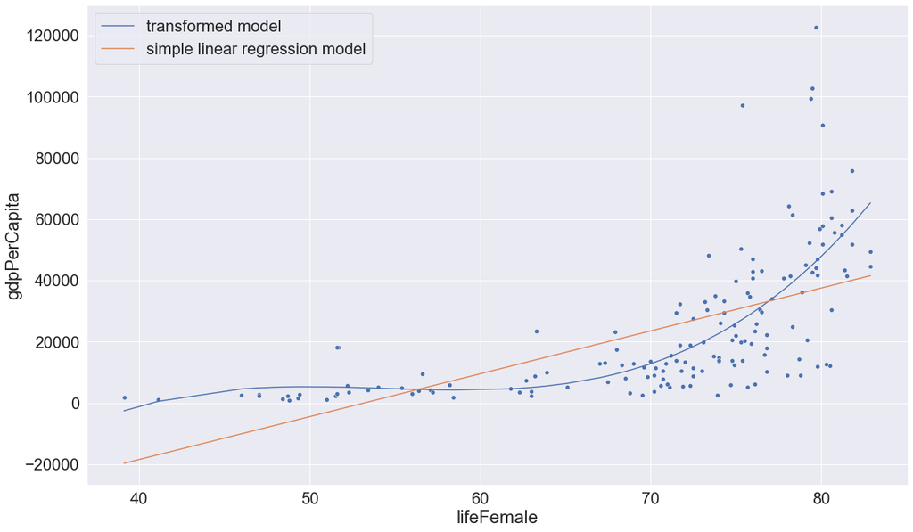

```python
#Transformed model
model = smf.ols(formula='gdpPerCapita~lifeFemale+I(lifeFemale**2)+I(lifeFemale**3)',data = social_indicators).fit()
sns.scatterplot(x = social_indicators.lifeFemale, y = social_indicators.gdpPerCapita)
sns.lineplot(x = social_indicators.lifeFemale, y = model.fittedvalues,label = 'transformed model')
#Simple linear regression model
model = smf.ols(formula='gdpPerCapita~lifeFemale',data = social_indicators).fit()
sns.lineplot(x = social_indicators.lifeFemale, y = model.fittedvalues, label = 'simple linear regression model')
plt.legend(loc='upper left')
```

Develop a model to predict `gdpPerCapita` with $P$ and `continent` as predictors.

1. Interpert the intercept term.
2. For a given value of $P$, are there any continents that **do not** have a signficant difference between their mean `gdpPerCapita` and that of Africa? If yes, then which ones, and why? If no, then why not? Consider a significance level of 5%.

*(4 + 4 points)*

```python
model = smf.ols(formula='gdpPerCapita~lifeFemale+continent',data = social_indicators).fit()
model.summary()
```

OLS Regression Results

| Dep. Variable: | gdpPerCapita | R-squared: | 0.508 |
| --- | --- | --- | --- |
| Model: | OLS | Adj. R-squared: | 0.488 |
| Method: | Least Squares | F-statistic: | 25.43 |
| Date: | Tue, 17 Jan 2023 | Prob (F-statistic): | 1.28e-20 |
| Time: | 11:25:01 | Log-Likelihood: | -1723.6 |
| No. Observations: | 155 | AIC: | 3461. |
| Df Residuals: | 148 | BIC: | 3483. |
| Df Model: | 6 |  |  |
| Covariance Type: | nonrobust |  |  |

|  | coef | std err | t | P>\|t\| | [0.025 | 0.975] |
| --- | --- | --- | --- | --- | --- | --- |
| Intercept | -7.208e+04 | 1.14e+04 | -6.305 | 0.000 | -9.47e+04 | -4.95e+04 |
| continent[T.Asia] | 1324.7980 | 4805.099 | 0.276 | 0.783 | -8170.667 | 1.08e+04 |
| continent[T.Europe] | 9167.0203 | 5785.650 | 1.584 | 0.115 | -2266.134 | 2.06e+04 |
| continent[T.North America] | -1.446e+04 | 5947.502 | -2.431 | 0.016 | -2.62e+04 | -2704.270 |
| continent[T.Oceania] | -1.429e+04 | 6063.764 | -2.357 | 0.020 | -2.63e+04 | -2307.304 |
| continent[T.South America] | -1.329e+04 | 6462.516 | -2.056 | 0.042 | -2.61e+04 | -516.198 |
| lifeFemale | 1393.4213 | 194.062 | 7.180 | 0.000 | 1009.931 | 1776.911 |

| Omnibus: | 67.873 | Durbin-Watson: | 1.942 |
| --- | --- | --- | --- |
| Prob(Omnibus): | 0.000 | Jarque-Bera (JB): | 231.081 |
| Skew: | 1.701 | Prob(JB): | 6.63e-51 |
| Kurtosis: | 7.920 | Cond. No. | 721. |

Notes:  
[1] Standard Errors assume that the covariance matrix of the errors is correctly specified.

The estimated mean GDP per capita of Africa for a zero life expectancy of female people (`lifefemale` = 0) is -$72080.

Based on the $p$-values, Asia and Europe do not have a significant difference between their mean `gdpPerCapita` and that of Africa, for a given value of $P$. Note that the level with no dummy variable - Africa is the baseline in this model. So we can directly make comparisons with Africa using the $p$-values of other dummy variables.

The model developed in the previous question has a limitation. It assumes that the increase in mean `gdpPerCapita` with a unit increase in $P$ does not depend on the `continent`.

1. Eliminate this limitation by including interaction of `continent` with $P$ in the model developed in the previous question. Print the model summary of the model with interactions.
2. Interpret the coefficient of any one of the interaction terms. *(4 + 4 points)*

```python
model = smf.ols(formula='gdpPerCapita~lifeFemale*continent',data = social_indicators).fit()
model.summary()
```

OLS Regression Results

| Dep. Variable: | gdpPerCapita | R-squared: | 0.605 |
| --- | --- | --- | --- |
| Model: | OLS | Adj. R-squared: | 0.574 |
| Method: | Least Squares | F-statistic: | 19.90 |
| Date: | Tue, 17 Jan 2023 | Prob (F-statistic): | 7.99e-24 |
| Time: | 11:28:59 | Log-Likelihood: | -1706.6 |
| No. Observations: | 155 | AIC: | 3437. |
| Df Residuals: | 143 | BIC: | 3474. |
| Df Model: | 11 |  |  |
| Covariance Type: | nonrobust |  |  |

|  | coef | std err | t | P>\|t\| | [0.025 | 0.975] |
| --- | --- | --- | --- | --- | --- | --- |
| Intercept | -1.723e+04 | 1.53e+04 | -1.129 | 0.261 | -4.74e+04 | 1.29e+04 |
| continent[T.Asia] | -1.094e+05 | 2.63e+04 | -4.156 | 0.000 | -1.61e+05 | -5.74e+04 |
| continent[T.Europe] | -2.774e+05 | 6.63e+04 | -4.185 | 0.000 | -4.08e+05 | -1.46e+05 |
| continent[T.North America] | -6.6e+04 | 4.88e+04 | -1.352 | 0.178 | -1.62e+05 | 3.05e+04 |
| continent[T.Oceania] | -1.367e+05 | 5.78e+04 | -2.364 | 0.019 | -2.51e+05 | -2.24e+04 |
| continent[T.South America] | -7830.3082 | 8.18e+04 | -0.096 | 0.924 | -1.69e+05 | 1.54e+05 |
| lifeFemale | 428.5595 | 264.214 | 1.622 | 0.107 | -93.711 | 950.830 |
| lifeFemale:continent[T.Asia] | 1755.1049 | 400.782 | 4.379 | 0.000 | 962.882 | 2547.328 |
| lifeFemale:continent[T.Europe] | 3944.6364 | 869.916 | 4.535 | 0.000 | 2225.080 | 5664.193 |
| lifeFemale:continent[T.North America] | 921.1328 | 667.359 | 1.380 | 0.170 | -398.031 | 2240.297 |
| lifeFemale:continent[T.Oceania] | 1898.4382 | 812.766 | 2.336 | 0.021 | 291.851 | 3505.026 |
| lifeFemale:continent[T.South America] | 135.3138 | 1134.388 | 0.119 | 0.905 | -2107.022 | 2377.650 |

| Omnibus: | 73.348 | Durbin-Watson: | 1.900 |
| --- | --- | --- | --- |
| Prob(Omnibus): | 0.000 | Jarque-Bera (JB): | 290.376 |
| Skew: | 1.785 | Prob(JB): | 8.82e-64 |
| Kurtosis: | 8.676 | Cond. No. | 5.23e+03 |

Notes:  
[1] Standard Errors assume that the covariance matrix of the errors is correctly specified.  
[2] The condition number is large, 5.23e+03. This might indicate that there are  
strong multicollinearity or other numerical problems.

Interpreting lifeFemale:continent[T.Asia]: For a unit increase in `lifefemale` for Asian countries, the estimated mean increase in GDP per capita is $1755 more than the mean increase in GDP per capita for Africa.

Use the model developed in the previous question to plot regression lines for Africa, Asia, and Europe. Put `gdpPerCapita` on the vertical axis and $P$ on the horizontal axis. Use a legend to distinguish among the regression lines of the three continents.

*(4 points)*

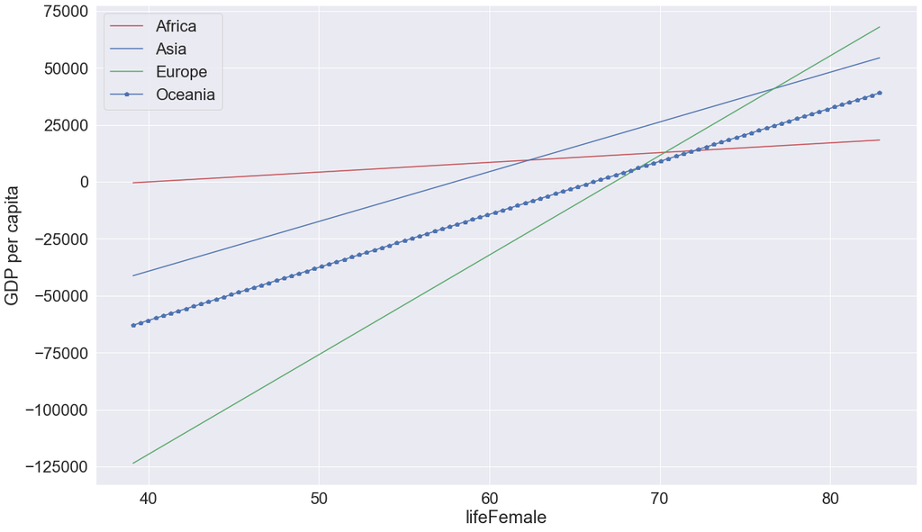

```python
#Visualizing the developed model with interaction terms
x = np.linspace(social_indicators.lifeFemale.min(),social_indicators.lifeFemale.max(),100)
plt.plot(x, model.params['lifeFemale']*x+model.params['Intercept'], '-r', label='Africa')
plt.plot(x, (model.params['lifeFemale']+model.params['lifeFemale:continent[T.Asia]'])*x+model.params['Intercept']+model.params['continent[T.Asia]'], '-b', label='Asia')
plt.plot(x, (model.params['lifeFemale']+model.params['lifeFemale:continent[T.Europe]'])*x+model.params['Intercept']+model.params['continent[T.Europe]'], '-g', label='Europe')
plt.plot(x, (model.params['lifeFemale']+model.params['lifeFemale:continent[T.Oceania]'])*x+model.params['Intercept']+model.params['continent[T.Oceania]'], '-p', label='Oceania')
plt.legend(loc='upper left')
plt.xlabel('lifeFemale')
plt.ylabel('GDP per capita')
plt.show()
```

Based on the plot develop in the previous question, which continent has the highest increase in mean `gdpPerCapita` for a unit increase in $P$, and which one has the least? Justify your answer.

*(2+2 points)*

Europe has the highest increase in mean `gdpPerCapita` for a unit increase in $P$ as the slope of its regression line is the highest. Africa has the least increase in mean `gdpPerCapita` for a unit increase in $P$, as the slope of its regression line is the least.